# 07_radians_from_arc_length

## 07_radians_from_arc_length

#### Question

1. Consider a circle with a radius of length $r=7.2$ meters. A [central angle](https://en.wikipedia.org/wiki/Central_angle), in [standard position](https://libraryguides.centennialcollege.ca/c.php?g=716824&p=5112868), subtends an arc of length $14.4$ meters.

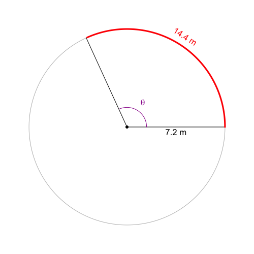

   **Find $\theta$ in radians**.

#### Question

2. Consider a circle with a radius of length $r=9.6$ meters. A [central angle](https://en.wikipedia.org/wiki/Central_angle), in [standard position](https://libraryguides.centennialcollege.ca/c.php?g=716824&p=5112868), subtends an arc of length $45.6$ meters.

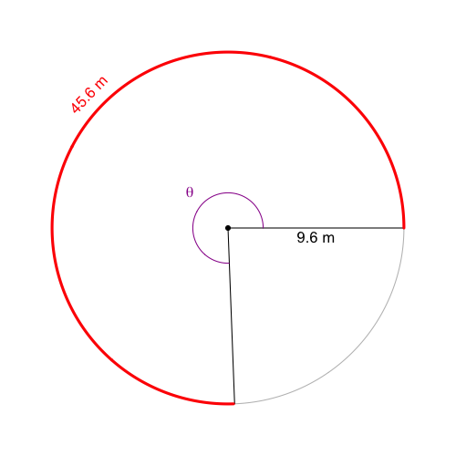

   **Find $\theta$ in radians**.

#### Question

3. Consider a circle with a radius of length $r=5.1$ meters. A [central angle](https://en.wikipedia.org/wiki/Central_angle), in [standard position](https://libraryguides.centennialcollege.ca/c.php?g=716824&p=5112868), subtends an arc of length $10.2$ meters.

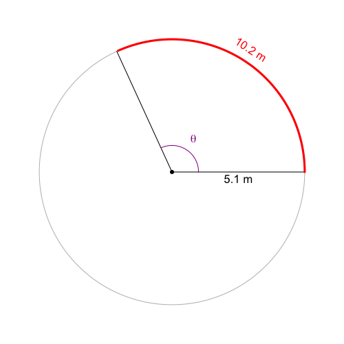

   **Find $\theta$ in radians**.

#### Question

4. Consider a circle with a radius of length $r=6.9$ meters. A [central angle](https://en.wikipedia.org/wiki/Central_angle), in [standard position](https://libraryguides.centennialcollege.ca/c.php?g=716824&p=5112868), subtends an arc of length $13.8$ meters.

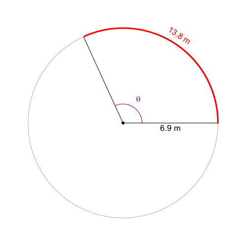

   **Find $\theta$ in radians**.

#### Question

5. Consider a circle with a radius of length $r=9$ meters. A [central angle](https://en.wikipedia.org/wiki/Central_angle), in [standard position](https://libraryguides.centennialcollege.ca/c.php?g=716824&p=5112868), subtends an arc of length $36.9$ meters.

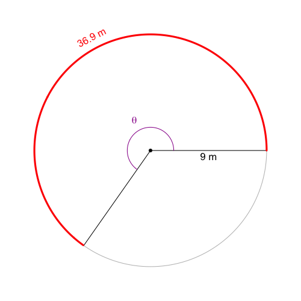

   **Find $\theta$ in radians**.

#### Question

6. Consider a circle with a radius of length $r=5$ meters. A [central angle](https://en.wikipedia.org/wiki/Central_angle), in [standard position](https://libraryguides.centennialcollege.ca/c.php?g=716824&p=5112868), subtends an arc of length $23.5$ meters.

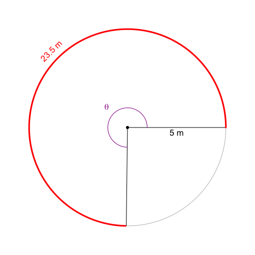

   **Find $\theta$ in radians**.

#### Question

7. Consider a circle with a radius of length $r=5$ meters. A [central angle](https://en.wikipedia.org/wiki/Central_angle), in [standard position](https://libraryguides.centennialcollege.ca/c.php?g=716824&p=5112868), subtends an arc of length $20.7$ meters.

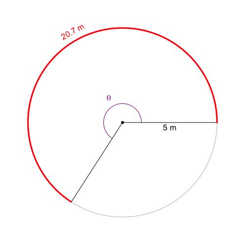

   **Find $\theta$ in radians**.

#### Question

8. Consider a circle with a radius of length $r=5$ meters. A [central angle](https://en.wikipedia.org/wiki/Central_angle), in [standard position](https://libraryguides.centennialcollege.ca/c.php?g=716824&p=5112868), subtends an arc of length $20.5$ meters.

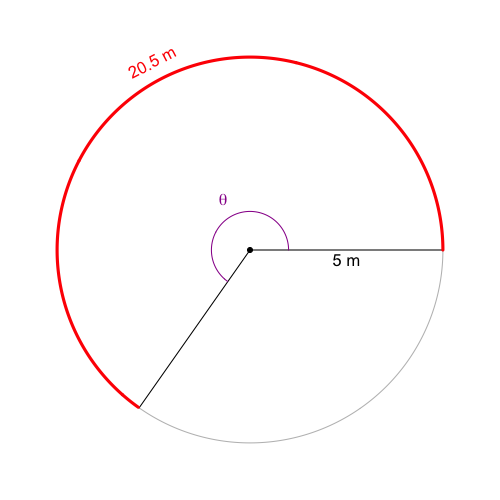

   **Find $\theta$ in radians**.